# fishash+ on the fishash authors’ simulations

Method, simulation design, results, and next steps

Author

gRNA-assignment investigation

Published

August 13, 2026

# 1 Method

Let $Y\in\mathbb{N}_0^{G\times C}$ be the observed guide-UMI count matrix, with guides indexed by $g\in\{1,\ldots,G\}$ and cells by $c\in\{1,\ldots,C\}$. Both fishash and fishash+ begin from a rank-1 model for ambient counts,

$$Y_{gc}^{\mathrm{ambient}}\sim\operatorname{Pois}(a_gd_c),$$

where $a_g\in[0,1]$, $\sum_{g=1}^G a_g=1$, and $d_c\in[0,\infty)$.

Thus $a_g$ is guide $g$’s share of the ambient pool and $d_c$ is the expected total ambient guide count in cell $c$. The normalization $\sum_g a_g=1$ makes the two factors identifiable. Both methods iteratively mask likely signal entries and refit this model so that real guide counts do not distort the estimated ambient composition.

## 1.1 fishash+ algorithm

**NoteAlgorithm 1: fishash+**

**Inputs:** guide-count matrix $Y$; target FDR $q=0.05$; maximum number of refits $R=10$; minimum assignable count $m=2$.

1. **Initialize.** Set the assignment mask to empty.
2. **Define the testing universe.** Exclude empty guide rows and empty cell columns. Let $G_+$ and $C_+$ be the respective numbers remaining, and set $n_{\mathrm{entries}}=G_+C_+$.
3. **Fit ambient factors.** Fit $\lambda_{gc}=\hat a_g\hat d_c$ by masked rank-1 Poisson completion. On the first iteration, use the unmasked matrix.
4. **Score entries.** For every observed nonzero entry, compute
   $$p_{gc}=P\{\operatorname{Pois}(\hat a_g\hat d_c)\ge Y_{gc}\}.$$
5. **Apply the inherited Guo–Sarkar rule.** Form a cell-level block p-value from the smallest guide-level p-value in each cell, apply BH across cells, and let $B$ be the number of selected cell blocks. The entry-level cutoff is $qB/n_{\mathrm{entries}}$.
6. **Assign guides.** Set
   $$A_{gc}=1\{p_{gc}\le qB/n_{\mathrm{entries}},\;Y_{gc}\ge m\}.$$
7. **Refit.** Update the mask using fishash’s unchanged refit schedule and repeat Steps 3–6 until the assignments stabilize or the refit limit is reached.

**Output:** the logical guide-by-cell assignment matrix $A$.

## 1.2 Where fishash+ differs from fishash

fishash is a per-entry contingency-table method. For each guide–cell pair, it forms a $2\times2$ table contrasting the focal guide with all other guides and the focal cell with all other cells, then applies a one-sided hypergeometric (Fisher exact) test conditional on the table margins.

The comparison is deliberately narrow. fishash+ retains fishash’s masked rank-1 completion, iterative mask schedule, Guo–Sarkar FDR procedure, minimum-count rule, and empty-row/empty-column handling. It changes two linked parts of the final entry test:

- **Cell exposure.** fishash’s hypergeometric test conditions on the raw cell guide-library total $Y_{:c}$. fishash+ uses the fitted ambient depth $\hat d_c$. The raw total contains true guide signal; at high MOI, one real guide can therefore inflate the background used to test another.
- **Tail calculation.** fishash uses a one-sided hypergeometric tail conditional on the row and column margins. fishash+ uses the unconditional Poisson upper tail under $\hat a_g\hat d_c$.

# 2 Simulation setting

## 2.1 GuideBender generative model

1. **Draw the number of infections per cell.** Let $K_c$ be the infection count assigned to modeled recovered cell $c$:
   $$K_c\sim
   \begin{cases}
   0, & \text{with probability }h,\\
   \operatorname{Pois}(\lambda)\mid\operatorname{Pois}(\lambda)\geq1,
   & \text{with probability }1-h.
   \end{cases}$$
   Here $\lambda$ is the pre-selection MOI: the underlying Poisson infection-rate parameter before the hurdle mixture and conditioning on at least one infection. In the figures and elsewhere in this report, MOI instead denotes the mean infection count per modeled recovered cell after those selection steps. The hurdle probability $h$ models imperfect filtering for infected cells: some uninfected cells remain in the recovered population. The simulator uses $h=0.1$, so 10% of modeled recovered cells receive zero infections and the remaining 90% receive at least one.
2. **Draw which gRNAs infected each cell.** Let $\pi_g$ be the population frequency of guide $g$, meaning the probability that any one infection event uses that guide. Draw the vector of frequencies $\pi$ from a symmetric Dirichlet distribution. Given $K_c$, allocate the infection events across guides, and let $J_{gc}$ be the number assigned to guide $g$:
   $$J_{\cdot c}\mid K_c\sim\operatorname{Multinomial}(K_c,\pi).$$
3. **Draw guide and cell characteristics.** Give each guide an expression factor $d_g^{\mathrm{guide}}$, and each cell a cellular-depth factor $d_c^{\mathrm{cell}}$, a droplet-depth factor $d_c^{\mathrm{drop}}$, a mean-one capture-efficiency factor $\epsilon_c$, and an exogenous-noise fraction $\rho_c$. The depth factors are lognormal, $\epsilon_c$ is Gamma, and $\rho_c$ is Beta. Let $\chi_g$ be the shared endogenous ambient profile and $b_g$ the dataset-wide bulk guide profile, both normalized to sum to one.
4. **Draw and add the count components.** Conditional on the infection assignments and guide and cell factors, independently draw
   $$Y_{gc}^{\mathrm{sig}}
   \sim\operatorname{NB}\!\left(
   \text{mean}=J_{gc}d_g^{\mathrm{guide}}(1-\rho_c)\epsilon_c
   d_c^{\mathrm{cell}},
   \ \text{dispersion}=1
   \right),$$
   $$Y_{gc}^{\mathrm{endo}}
   \sim\operatorname{Pois}\!\left(
   \chi_g(1-\rho_c)\epsilon_c d_c^{\mathrm{drop}}
   \right),$$
   and
   $$Y_{gc}^{\mathrm{exo}}
   \sim\operatorname{Pois}\!\left(
   b_g\rho_c\epsilon_c
   \left(d_c^{\mathrm{cell}}+d_c^{\mathrm{drop}}\right)
   \right).$$
   The two ambient components remain conditionally Poisson in the primary model. Signal and endogenous ambient were physically present in the droplet and therefore receive the non-exogenous fraction $1-\rho_c$, whereas exogenous molecules arise through barcode swapping or related artifacts and receive $\rho_c$. Finally, set
   $$Y_{gc}=Y_{gc}^{\mathrm{sig}}+Y_{gc}^{\mathrm{endo}}+Y_{gc}^{\mathrm{exo}}.$$
   The implementation adds a finite-sample calibration to this scientific description.[^1]

## 2.2 Scenarios and scoring

| Setting | Guides; cells | Target median guide UMIs/cell | SNR | Exogenous ambient | Hurdle | Ambient distribution |
| --- | --- | --- | --- | --- | --- | --- |
| **Primary setting** | 200 guides; 20,000 cells | 100 UMIs/cell | 4 | 25% | $h=0.1$ | Conditionally Poisson |
| **NB-ambient setting** | 200 guides; 20,000 cells | 100 UMIs/cell | 4 | 25% | $h=0.1$ | NB ambient |
| **Increased exogenous setting** | 200 guides; 20,000 cells | 20 UMIs/cell | 1 | 75% | $h=0.1$ | Conditionally Poisson |

Accuracy is the fishash paper’s pooled per-entry precision, recall, and F1 on the full guide-by-cell matrix. fishash+, fishash, and sceptre are computed on the simulated matrices. Other published methods are available only as digitized medians from the paper, with approximately ±0.02 F1 read-off precision. “Best other” is a pointwise envelope: its method identity can change across settings.

# 3 Results

## 3.1 Headline results

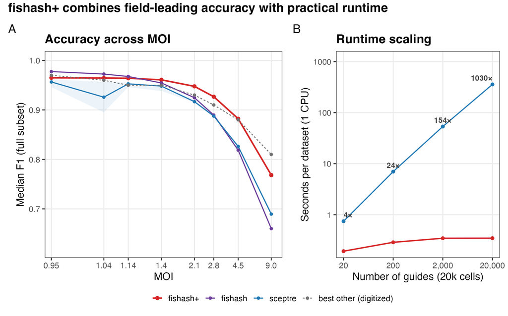

**Accuracy and runtime.** Panel A compares fishash+, fishash, sceptre mixture, and the pointwise best of the other eight published methods. Exact curves are medians over the 10 common author-seeded datasets; shaded bands are IQRs. The grey curve is digitized. Panel B shows median single-CPU runtime on 20k-cell simulations.

## 3.2 Robustness: variance and mean boundaries

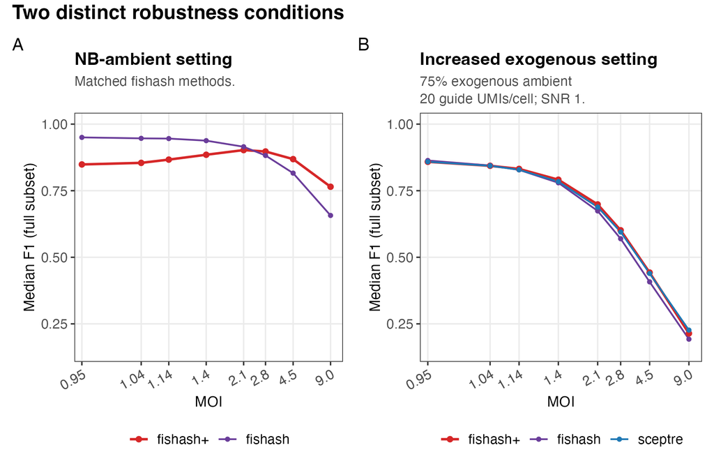

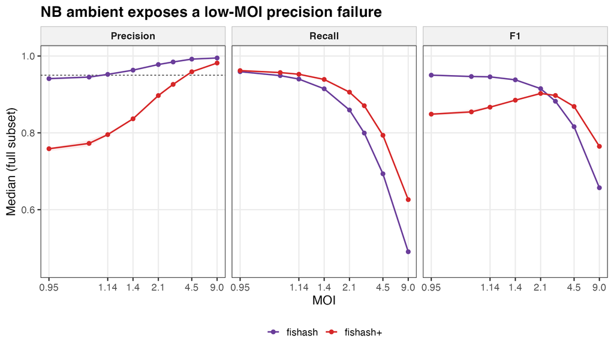

**Detailed variance robustness.** Precision, recall, and F1 for fishash+ and fishash in the NB-ambient setting. Matched sceptre and numeric published-competitor results are unavailable for this scenario. The two-method decomposition shows that fishash+’s low-MOI F1 loss comes from reduced precision rather than reduced recall.

# 4 Conclusions and next steps

The next steps are:

1. **Implement fishash+ efficiently.** As the leading candidate for integration into sceptre, fishash+ should be implemented next. The precise integration boundary—inside sceptre or elsewhere in the surrounding workflow—remains an open implementation decision.
2. **Adopt the GuideBender simulation framework.** Use its simulation structure as the starting point for the sceptre benchmark, without treating its fixed parameter regimes as benchmark defaults. Calibrate parameter values and choose sweep dimensions in future work.
3. **Perform the benchmark.** Use the already available barnyard evaluation where relevant, and build and run a more comprehensive simulation benchmark from the GuideBender framework.

## Footnotes

[^1]: The implementation first draws the latent signal Gamma rate, then applies one common factor to all latent components so that the realized cohort median total latent guide abundance hits the scenario target exactly; this finite-sample calibration preserves the relative signal/ambient structure.